# Clase 7: Modelos lineales Generalizados Mixtos

[figure not shown]

Literatura recomendada para compreder los GLLM, [Harrison *et al*. 2018](https://doi.org/10.7717/peerj.4794)

En estudios ecológicos y de conservación, a veces se toman mediciones de los mismos individuos o sitios de muestreo en más de una ocasión. Un estudio de este tipo se denomina un `diseño de medidas repetidas`. Estos datos también pueden ser recolectados a intervalos de tiempo específicos, en cuyo caso los datos conforman un `estudio longitudinal`.

Para nuestro ejemplo, utilizaremos una base de datos sobre aves en Honduras. La base de datos contiene información sobre la abundancia de aves recopilada mediante puntos de conteo y de dos a tres réplicas por sitio. Asimismo, incluye variables de la vegetación, como área basal, y datos de paisaje, como el porcentaje de bosque y de café bajo sombra.

**Los objetivos del estudio fueron evaluar la relación de la abundancia de aves con la estructura de la vegetación y el paisaje.:**

### Contenido

#### Base de datos

```r
aves <- read.csv("docs/data/AvesHabitatUm.csv")
```

Empezaremos con una ligera inspección de los datos.

```r
str(aves)
```

```
## 'data.frame':    1883 obs. of  37 variables:
##  $ Site        : int  1 1 1 1 1 1 1 1 1 1 ...
##  $ SiteName    : chr  "El Plan de Tule #1" "El Plan de Tule #1" "El Plan de Tule #1" "El Plan de Tule #1" ...
##  $ VEGID       : chr  "1" "1" "1" "1" ...
##  $ Type        : chr  "F" "F" "F" "F" ...
##  $ LAT         : num  15.2 15.2 15.2 15.2 15.2 ...
##  $ LONG        : num  -87.4 -87.4 -87.4 -87.4 -87.4 ...
##  $ ALTITUDE    : num  879 879 879 879 879 879 879 879 879 879 ...
##  $ Aspect      : int  114 114 114 114 114 114 114 114 114 114 ...
##  $ Slope       : chr  "M" "M" "M" "M" ...
##  $ Description : chr  "Forest > 100m in all directions. Canopy cover is minimal. Mature trees are mostly pine. Moderate slope. Some gr"| __truncated__ "Forest > 100m in all directions. Canopy cover is minimal. Mature trees are mostly pine. Moderate slope. Some gr"| __truncated__ "Forest > 100m in…
##  $ Understory  : chr  "P" "P" "P" "P" ...
##  $ Moss        : chr  "FALSO" "FALSO" "FALSO" "FALSO" ...
##  $ H2O         : chr  "FALSO" "FALSO" "FALSO" "FALSO" ...
##  $ Edge        : chr  "FALSO" "FALSO" "FALSO" "FALSO" ...
```

[output cut: 23 more lines]

Como se puede observar, la base de datos no está depurada ni filtrada, por lo que necesita una ligera limpieza y filtrado de las variables que queremos evaluar. Para esto, utilizaremos el paquete `tidyverse` y nos quedaremos con las siguientes variables:

- Site
- Type
- ALTITUDE
- pforest.
- sforest.
- coffee.
- Area_Basal
- Group_cover
- Subcanopy
- Especies
- Replica

#### Limpieza de la base de datos

```r
library(tidyverse)

AvesLim <- aves %>%
  select(Site, Type, ALTITUDE, pforest., sforest., coffee.,
         Area_Basal, Group_cover, Subcanopy, Especies, Replica) %>%
  filter(Especies %in% c("CARPUS", "SETVIR", "MNIVAR",
                         "BASRUF", "SETMAG", "MIOOLE",
                         "VERCHR")) %>%
  mutate(Site = as.factor(Site),
         Type =  as.factor(Type),
         Especies = as.factor(Especies),
         Replica = as.factor(Replica)) %>%
  group_by(Site, Type, ALTITUDE, pforest., sforest., coffee.,
         Area_Basal, Group_cover, Subcanopy, Especies, Replica) %>%
  summarise(Abundancia = n()) %>%
  group_by(Site, Type, ALTITUDE, pforest., sforest., coffee.,
         Area_Basal, Group_cover, Subcanopy, Especies, Replica) %>%
  pivot_wider(names_from = Especies, values_from = Abundancia,
              values_fill = 0) %>%
  pivot_longer(cols = MNIVAR:MIOOLE, names_to = "Especies",
               values_to = "Abundance") %>%
  ungroup()

str(AvesLim)
```

```
## tibble [600 × 12] (S3: tbl_df/tbl/data.frame)
##  $ Site       : Factor w/ 41 levels "3","5","6","8",..: 1 1 1 1 1 1 1 1 1 1 ...
##  $ Type       : Factor w/ 2 levels "C","F": 1 1 1 1 1 1 1 1 1 1 ...
##  $ ALTITUDE   : num [1:600] 825 825 825 825 825 825 825 825 825 825 ...
##  $ pforest.   : int [1:600] 0 0 0 0 0 0 0 0 0 0 ...
##  $ sforest.   : int [1:600] 0 0 0 0 0 0 0 0 0 0 ...
##  $ coffee.    : int [1:600] 94 94 94 94 94 94 94 94 94 94 ...
##  $ Area_Basal : num [1:600] 7.8 7.8 7.8 7.8 7.8 7.8 7.8 7.8 7.8 7.8 ...
##  $ Group_cover: int [1:600] 19 19 19 19 19 19 19 19 19 19 ...
##  $ Subcanopy  : int [1:600] 1 1 1 1 1 1 1 1 1 1 ...
##  $ Replica    : Factor w/ 3 levels "1","2","3": 1 1 1 1 1 1 2 2 2 2 ...
##  $ Especies   : chr [1:600] "MNIVAR" "SETMAG" "SETVIR" "CARPUS" ...
##  $ Abundance  : int [1:600] 1 1 2 0 0 0 1 0 1 0 ...
```

La descripción de las variables es la siguiente:

Site: Factor que representa un código único para cada sitio de muestreo. Type: Factor de dos niveles que indica si el sitio de muestreo es un bosque (F) o un cultivo de café (C). ALTITUDE: Variable continua que indica la elevación en metros sobre el nivel del mar. pforest.: Variable numérica que indica el porcentaje de bosque primario alrededor del sitio de muestreo. sforest.: Variable numérica que indica el porcentaje de bosque secundario alrededor del sitio de muestreo. coffee.: Variable numérica que indica el porcentaje de café bajo sombra alrededor del sitio de muestreo. Area_Basal: Indica el área basal. Group_cover: Indica la cobertura en el sotobosque. Subcanopy: Indica la cobertura en el subdosel. Especies: Factor que indica la especie a estudiar. Replica: Factor que indica el número de visita al sitio de muestreo. Abundance: Variable discreta que indica la abundance de aves.

#### Exploracion de los datos

##### Valores nulos `NAs`

```r
colSums(is.na(AvesLim))
```

```
##        Site        Type    ALTITUDE    pforest.    sforest.     coffee.
##          18          18          18          18          18          18
##  Area_Basal Group_cover   Subcanopy     Replica    Especies   Abundance
##          18          18          18           0           0           0
```

##### Valores extremos

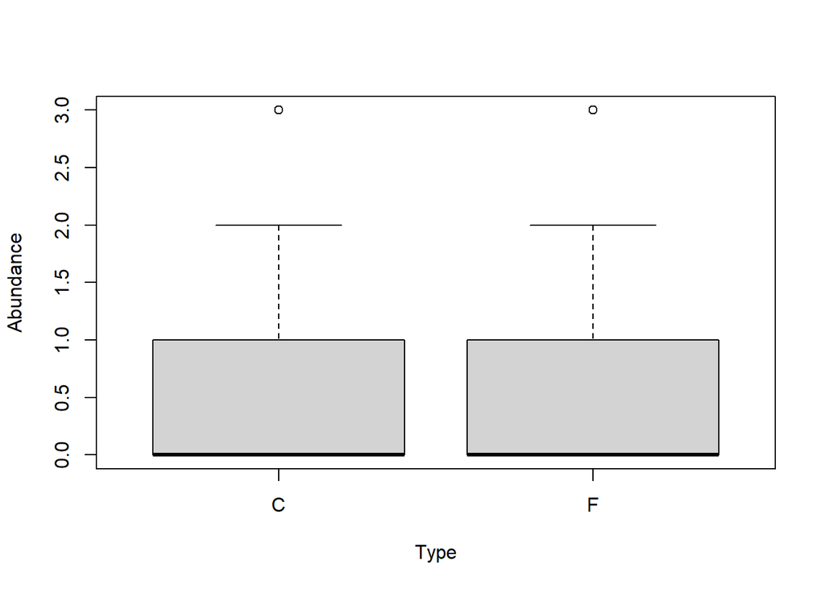

```r
boxplot(Abundance ~ Type, data= AvesLim)
```

##### Zeros en la variable respuesta?

```r
sum(AvesLim$Abundance == 0) * 100 /nrow(AvesLim)
```

```
## [1] 57.66667
```

##### Multicolialinidad entre variables predictoras

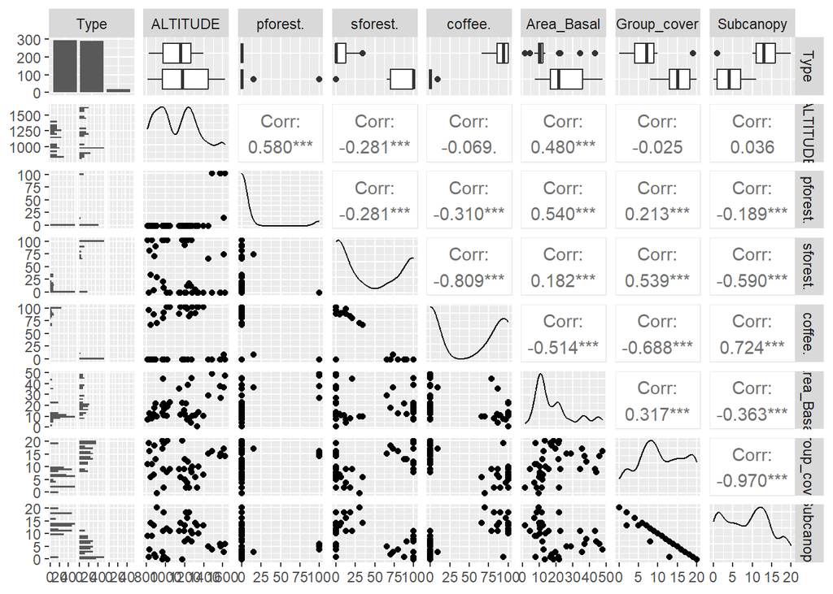

```r
library(GGally)

ggpairs(AvesLim[,2:9])
```

```r
library(car)
vif(glm(Abundance ~ Type + ALTITUDE +
          pforest. + sforest. + coffee. +
          Area_Basal + Group_cover + Subcanopy,
        family = "poisson", data= AvesLim))
```

```
##        Type    ALTITUDE    pforest.    sforest.     coffee.  Area_Basal
##   58.344050    2.452051   12.559834   27.112669   69.187577    2.085540
## Group_cover   Subcanopy
##   22.097953   25.687386
```

#### Modelos candidatos

```r
AvesLim <- AvesLim %>%
  na.omit()

library(lme4)
AvesM1 <- glmer.nb(Abundance ~ sforest. +
          Area_Basal + Group_cover + (1|Site) + (1|Especies) + (1|Replica),
        family = "poisson", data= AvesLim, na.action = na.fail )
vif(AvesM1)
```

```
##    sforest.  Area_Basal Group_cover
##    1.386310    1.138346    1.546150
```

#### Selección del modelo

```r
library(knitr )
library(MuMIn)
library(AICcmodavg)

kable(dredge(AvesM1))
```

|  | (Intercept) | Area_Basal | Group_cover | sforest. | df | logLik | AICc | delta | weight |
| --- | --- | --- | --- | --- | --- | --- | --- | --- | --- |
| 5 | -0.8989057 | NA | NA | -0.0033475 | 6 | -481.7203 | 975.5868 | 0.000000 | 0.36756159 |
| 7 | -0.9671824 | NA | 0.0085702 | -0.0039574 | 7 | -481.5375 | 977.2702 | 1.683450 | 0.15840674 |
| 6 | -0.9507747 | 0.0030374 | NA | -0.0034609 | 7 | -481.5827 | 977.3605 | 1.773694 | 0.15141798 |
| 1 | -1.0458380 | NA | NA | NA | 5 | -483.7473 | 977.5987 | 2.011913 | 0.13441535 |
| 8 | -0.9898980 | 0.0021239 | 0.0068522 | -0.0039109 | 8 | -481.4776 | 979.2065 | 3.619754 | 0.06016037 |
| 3 | -0.9696252 | NA | -0.0068774 | NA | 6 | -483.6000 | 979.3462 | 3.759410 | 0.05610281 |
| 2 | -1.0728212 | 0.0014288 | NA | NA | 6 | -483.7202 | 979.5864 | 3.999658 | 0.04975256 |
| 4 | -1.0012893 | 0.0028301 | -0.0088440 | NA | 7 | -483.5034 | 981.2019 | 5.615166 | 0.02218259 |

```r
AvesM2 <- glmer.nb(Abundance ~ sforest. + (1|Site) + (1|Especies) + (1|Replica),
        family = "poisson", data= AvesLim, na.action = na.fail )
```

#### Validación del modelo

Para la validación, utilizaremos el paquete `DHARMa`.

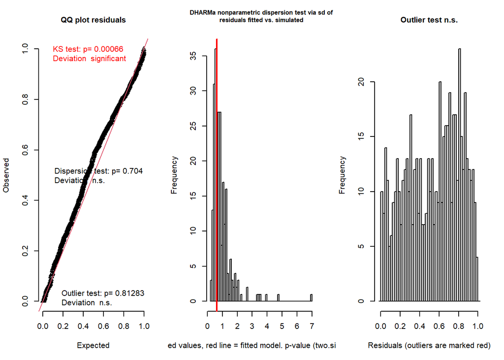

```
## $uniformity
##
##  Asymptotic one-sample Kolmogorov-Smirnov test
##
## data:  simulationOutput$scaledResiduals
## D = 0.082975, p-value = 0.0006617
## alternative hypothesis: two-sided
##
##
## $dispersion
##
##  DHARMa nonparametric dispersion test via sd of residuals fitted vs.
##  simulated
##
## data:  simulationOutput
## dispersion = 0.65686, p-value = 0.704
## alternative hypothesis: two.sided
##
##
## $outliers
##
##  DHARMa outlier test based on exact binomial test with approximate
##  expectations
##
## data:  simulationOutput
## outliers at both margin(s) = 5, observations = 582, p-value = 0.8128
## alternative hypothesis: true probability of success is not equal to 0.007968127
## 95 percent confidence interval:
##  0.002795211 0.019934042
## sample estimates:
## frequency of outliers (expected: 0.00796812749003984 )
##                                            0.008591065
```

[output not shown]

```r
library(DHARMa)
testResiduals(AvesM2)
```

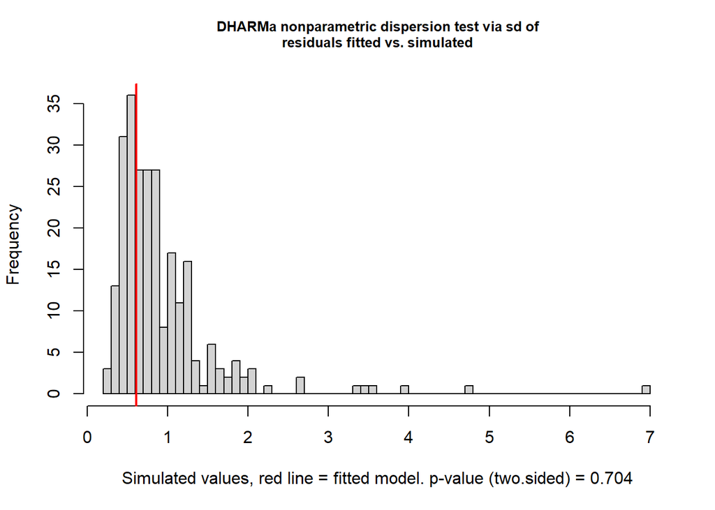

```
##
##  DHARMa nonparametric dispersion test via sd of residuals fitted vs.
##  simulated
##
## data:  simulationOutput
## dispersion = 0.65686, p-value = 0.704
## alternative hypothesis: two.sided
```

```r
testDispersion(AvesM2)
```

#### Interpretacion del Modelo

```r
summary(AvesM2)
```

```
## Generalized linear mixed model fit by maximum likelihood (Laplace
##   Approximation) [glmerMod]
##  Family: Negative Binomial(25465.3)  ( log )
## Formula: Abundance ~ sforest. + (1 | Site) + (1 | Especies) + (1 | Replica)
##    Data: AvesLim
##
##      AIC      BIC   logLik deviance df.resid
##    975.4   1001.6   -481.7    963.4      576
##
## Scaled residuals:
##     Min      1Q  Median      3Q     Max
## -1.2218 -0.6043 -0.3634  0.5386  3.8785
##
## Random effects:
##  Groups   Name        Variance Std.Dev.
##  Site     (Intercept) 0.05099  0.2258
##  Especies (Intercept) 0.48612  0.6972
##  Replica  (Intercept) 0.13788  0.3713
## Number of obs: 582, groups:  Site, 41; Especies, 6; Replica, 3
##
## Fixed effects:
##              Estimate Std. Error z value Pr(>|z|)
## (Intercept) -0.898970   0.372302  -2.415   0.0158 *
## sforest.    -0.003348   0.001628  -2.057   0.0397 *
## ---
## Signif. codes:  0 '***' 0.001 '**' 0.01 '*' 0.05 '.' 0.1 ' ' 1
##
## Correlation of Fixed Effects:
##          (Intr)
## sforest. -0.163
```

#### Gráficos

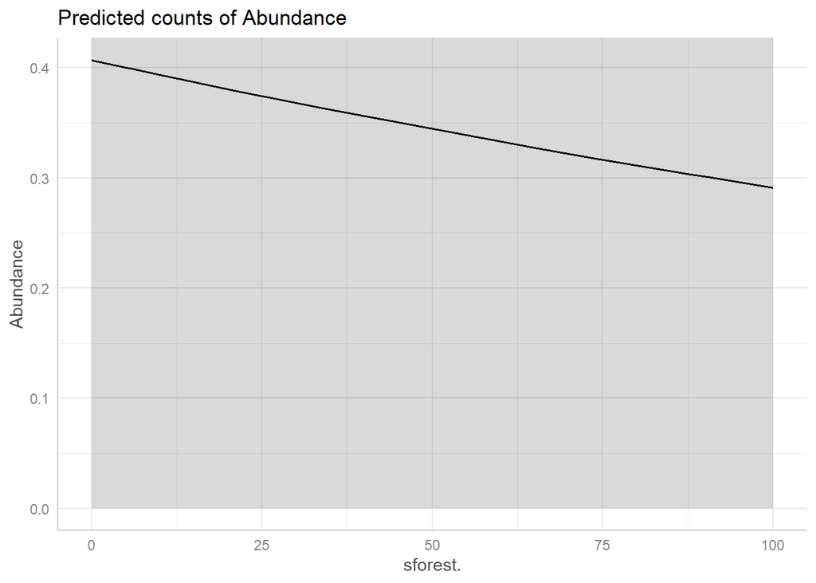

```r
library(ggeffects)

plot(ggpredict(AvesM2, type = "re", terms = c("sforest."),
               back_transform = TRUE, ci.lvl = 0.95))
```

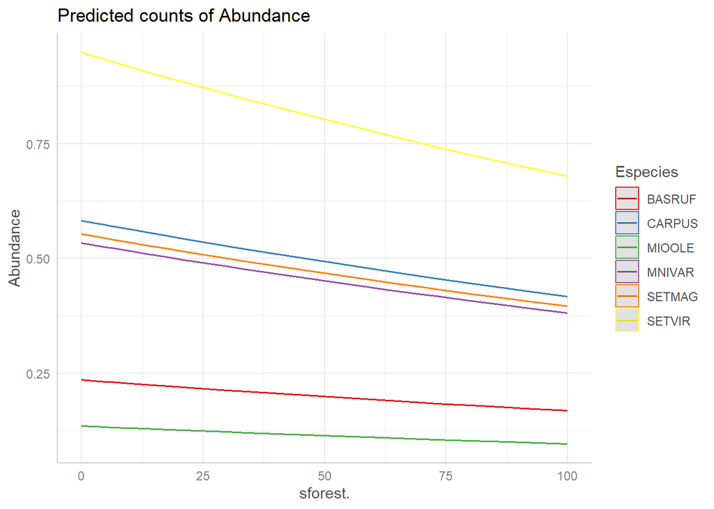

```r
plot(ggpredict(AvesM2, type = "re", terms = c("sforest.", "Especies"),
               back_transform = TRUE, ci.lvl = FALSE))
```

#### Ejercicio

- Seguir las indicaciones brindadas por David Murillo.